# Bootstrap

# Bootstrapping Approach

Bootstrapping is a resampling technique to estimate statistics on a population by sampling a dataset with replacement.

A useful feature of the bootstrap method is that the resulting sample of estimations often forms a Gaussian distribution. In additional to summarizing this distribution with a central tendency, measures of variance can be given, such as standard deviation and standard error. Further, a confidence interval can be calculated and used to bound the presented estimate. This is useful when presenting the estimated skill of a machine learning model. (https://machinelearningmastery.com/a-gentle-introduction-to-the-bootstrap-method/)

Seth has proposed that the best way of using this approach is to sample the genes at random, n being the number of canon or noncanon genes that were fed into that run. The count will then be the number of genes under selection that occur in that sample. These genes being the genes - regardless of class - that were found to be under selection in that lineage codeml run. Though I'm not sure if I wholly understand the logic yet, the proposal is that this will produce a distribution of "background selection" against which we can there compare the number of canon / noncanon genes under selection against.

I'm going to test this out on an origin that has fewer genes under selection, one that has many, and then one somewhere in between.

First, I need a table that tells me all the descriptive stats (such as genes under selection per lineage), so lets start there.

## Getting Counts

```r
summary(data.all)
```

```
      Gene          lnL_Null            lnL_Alt               LRT
 Arp1   :    9   Min.   :-86976.85   Min.   :-86976.85   Min.   :-118.3910
 B-gluc1:    9   1st Qu.: -8718.99   1st Qu.: -8718.24   1st Qu.:   0.0000
 Cox6c  :    9   Median : -5357.88   Median : -5357.42   Median :   0.0000
 CPR14  :    9   Mean   : -6900.51   Mean   : -6899.52   Mean   :   1.9961
 CPR19  :    9   3rd Qu.: -3282.11   3rd Qu.: -3280.99   3rd Qu.:   0.2329
 CSP6   :    9   Max.   :    -4.01   Max.   :    -4.01   Max.   : 306.7800
 (Other):53712
        SocOrigin          Class        Gene_Desc             pvalue
 AllComplex  : 5989   Canon   : 1647   Length:53766       Min.   :0.0000
 AllOrigin   : 5989   NonCanon: 7832   Class :character   1st Qu.:0.6293
 AllOriginEpi: 5989   Random  :44287   Mode  :character   Median :1.0000
 Halictid    : 5989                                       Mean   :0.7804
 Meli        : 5989                                       3rd Qu.:1.0000
 Xylo        : 5989                                       Max.   :1.0000
 (Other)     :17832
   adj_pvalue
 Min.   :0.0000
 1st Qu.:1.0000
 Median :1.0000
 Mean   :0.9666
 3rd Qu.:1.0000
 Max.   :1.0000
```

Check for duplicates

```r
nrow(data.all) == nrow(data.all[!duplicated(data.all),])
```

```
[1] TRUE
```

Test this out.

Pick three origins at random

```r
head(test3)
```

```
         Gene  lnL_Null   lnL_Alt      LRT SocOrigin    Class
23949    Arp1 -3664.219 -3664.088 0.263346   CorbSoc    Canon
23950 B-gluc1 -8569.747 -8569.747 0.000000   CorbSoc    Canon
23951   Cox6c -1488.839 -1488.839 0.000000   CorbSoc NonCanon
23952   CPR14 -1852.055 -1852.055 0.000000   CorbSoc NonCanon
23953   CPR19 -3262.068 -3262.068 0.000000   CorbSoc NonCanon
23954    CSP6 -1980.492 -1980.492 0.000000   CorbSoc NonCanon
                                    Gene_Desc    pvalue adj_pvalue
23949                actin related protein 1  0.6078307          1
23950  beta-1,3-glucan recognition protein 1  1.0000000          1
23951       cytochrome c oxidase subunit VIc  1.0000000          1
23952                   cuticular protein 14  1.0000000          1
23953                   cuticular protein 19  1.0000000          1
23954                 chemosensory protein 6  1.0000000          1
```

Check specifically there are no gene duplications within each

```r
nrow(test3) == nrow(test3[!duplicated(test3$Gene),])
```

```
[1] TRUE
```

Ok I trust it. Moving on.

Let's write a function that will go through each of the tested lineages, extract them from the master dataframe and count genes in, genes under selection per class, etc.

```r
col.headers <- c("LineageTested", "GenesInput", "CanonInput", "NonCanonInput", "RandomInput", "GenesUnderSel", "CanonUnderSel", "NonCanonUnderSel", "RandomUnderSel")
out <- matrix(ncol = length(col.headers), nrow = length(soc.list))
for (i in 1:length(soc.list)){
  ext <- data.all[data.all$SocOrigin == paste(soc.list[i]),]
  soc <- paste(soc.list[i])
  total <- nrow(ext)
  tot.can <- as.numeric(nrow(ext[ext$Class == "Canon",]))
  tot.non <- nrow(ext[ext$Class == "NonCanon",])
  tot.ran <- nrow(ext[ext$Class == "Random",])
  tot.sel <- nrow(ext[ext$adj_pvalue < 0.05,])
  sel.can <- nrow(ext[ext$Class == "Canon" & ext$adj_pvalue < 0.05,])
  sel.non <- nrow(ext[ext$Class == "NonCanon" & ext$adj_pvalue < 0.05,])
  sel.ran <- nrow(ext[ext$Class == "Random" & ext$adj_pvalue < 0.05,])
  chain <- c(soc, total, tot.can, tot.non, tot.ran, tot.sel, sel.can, sel.non, sel.ran)
  out[i,] <- chain
}
master.count <- as.data.frame(out)
colnames(master.count) <- col.headers
master.count
```

```
  LineageTested GenesInput CanonInput NonCanonInput RandomInput GenesUnderSel
1    AllComplex       5989        183           872        4934            48
2     AllOrigin       5989        183           872        4934            19
3  AllOriginEpi       5989        183           872        4934            11
4          Apis       5981        183           870        4928           101
5       CorbSoc       5901        183           865        4853            12
6    CorbSocEpi       5950        183           865        4902             4
7      Halictid       5989        183           872        4934           401
8          Meli       5989        183           872        4934           775
9          Xylo       5989        183           872        4934            58
  CanonUnderSel NonCanonUnderSel RandomUnderSel
1             2                4             42
2             0                1             18
3             1                2              8
4             3               16             82
5             0                1             11
6             0                2              2
7            12               55            334
8            27              103            645
9             3                9             46
```

Now for the bootstrapping

## Bootstrap

### Test

I'm going to write this off-script, and test it out on a lineage with lots of selection first.

```r
master.count[which.max(master.count$GenesUnderSel),]
```

```
  LineageTested GenesInput CanonInput NonCanonInput RandomInput GenesUnderSel
8          Meli       5989        183           872        4934           775
  CanonUnderSel NonCanonUnderSel RandomUnderSel
8            27              103            645
```

```r
master.count
```

```
             LineageTested GenesInput CanonInput NonCanonInput RandomInput
AllComplex      AllComplex       5989        183           872        4934
AllOrigin        AllOrigin       5989        183           872        4934
AllOriginEpi  AllOriginEpi       5989        183           872        4934
Apis                  Apis       5981        183           870        4928
CorbSoc            CorbSoc       5901        183           865        4853
CorbSocEpi      CorbSocEpi       5950        183           865        4902
Halictid          Halictid       5989        183           872        4934
Meli                  Meli       5989        183           872        4934
Xylo                  Xylo       5989        183           872        4934
             GenesUnderSel CanonUnderSel NonCanonUnderSel RandomUnderSel
AllComplex              48             2                4             42
AllOrigin               19             0                1             18
AllOriginEpi            11             1                2              8
Apis                   101             3               16             82
CorbSoc                 12             0                1             11
CorbSocEpi               4             0                2              2
Halictid               401            12               55            334
Meli                   775            27              103            645
Xylo                    58             3                9             46
```

For the canon genes I need to:

- make a list of all genes that were input into the Meli run
- specify the number of canon genes that were input which will be used as the "n" of genes to be sampled from the background list of genes
- make a list of all the genes that were considered under selection in the Meli run
- take note of the number of genes picked at random that were under selection in the Meli run
- put the sample back into the "population" and sample again (x1000 to test)

Canon

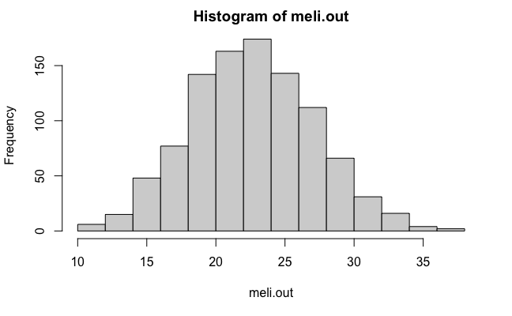

```r
dummy.sel <- function(x,y){
  class <- x
  soc <- y
  if ( class == "Canon" || class == "NonCanon"){
    des <- "CanonInput"
  } else {
    des <- "NonCanonInput"
  }
  pop <- droplevels(data.all$Gene[data.all$SocOrigin == paste(soc)])
  n <- master.count[soc,des]
  game <- droplevels(data.all$Gene[data.all$SocOrigin == paste(soc) &
                                     data.all$adj_pvalue < 0.05])
  catch <- sample(pop, size=n, replace = T)
  hit <- sum(as.numeric(game %in% catch))
  return(hit)
}

meli.out <- rep(0,999)
for (i in 1:999){
  meli.out[i] <- dummy.sel("Canon", "Meli")
}
hist(meli.out)
```

So it works making distributions with lineages that have a relatively large number of genes exhibiting signs of positive selection ... but is it going to work when there are small numbers of genes under selection

(I'm guessing not)

```r
master.count[which.min(master.count$GenesUnderSel),]
```

```
           LineageTested GenesInput CanonInput NonCanonInput RandomInput
CorbSocEpi    CorbSocEpi       5950        183           865        4902
           GenesUnderSel CanonUnderSel NonCanonUnderSel RandomUnderSel
CorbSocEpi             4             0                2              2
```

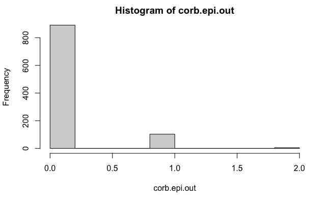

```r
corb.epi.out <- rep(0,999)
for (i in 1:999){
  corb.epi.out[i] <- dummy.sel("Canon", "CorbSocEpi")
}
hist(corb.epi.out)
```

I. Was. Right. Unfortunately.

```r
49*.85
```

```
[1] 41.65
```